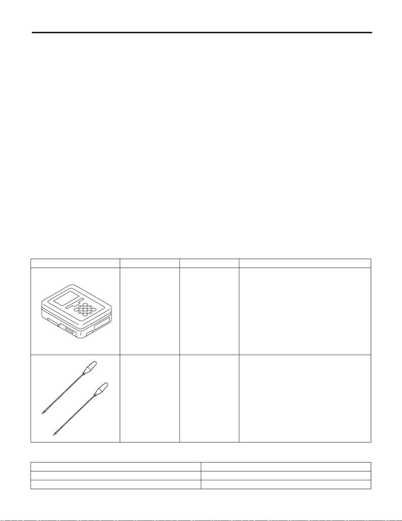

General Description

POWER ASSISTED SYSTEM (POWER STEERING) (DIAGNOSTICS)

3. General Description

A: CAUTION

1. SRS AIRBAG SYSTEM

The airbag system wiring harness is routed near the power steering control module.

CAUTION:

B: INSPECTION

Before performing diagnosis, check the following items which might be affecting the power steering problem.

1. BATTERY

Measure the battery voltage and check electrolyte.

Standard voltage: 12 V or higher (must not drop below 10 V during operation under electrical load)

Specific gravity: 1.260 or more

2. TIRES

C: PREPARATION TOOL

1. SPECIAL TOOL

2. GENERAL TOOL

ILLUSTRATION TOOL NUMBER DESCRIPTION REMARKS

1B022XU0 SUBARU SELECT

MONITOR III KIT

Used for troubleshooting the electrical system.

34199AG100 SPECIAL TOOL

HARNESS

Used for troubleshooting the electrical system.

TOOL NAME REMARKS

Circuit tester Used for measuring resistance, voltage and current.

Oscilloscope Used for measuring the sensor.

ST1B022XU0

ST34199AG100